# 합계출산율과 소비자물가

John Doe

2023 5 1

# Topic : 출산율에 미치는 소비자물가 분석

## 1. Data Definition

## 2. EDA & Preprocessing

```r
library(reshape2)
library(dplyr)
library(tidyverse)
library(tsibble)
library(colorspace)
library(gganimate)
library(fmsb)
library(car)
library(leaps)
library(moonBook)
library(nparcomp)
library(pgirmess)
source("acornProjTeam.R")
```

### 2.1. 데이터 불러오기 및 컬럼명 변경

```r
file.path <- "C:\\RWork\\TeamProject\\data\\source\\시도별합계출산율_final.csv"
birth.rate <- read.csv(file.path, header = T, encoding = "EUC-KR", fileEncoding = "EUC-KR")

file.path <- "C:\\RWork\\TeamProject\\data\\source\\품목별_소비자물가지수_품목성질별_2020100__20230428102420.csv"
consumer.prices <- read.csv(file.path, header = T, encoding = "EUC-KR", fileEncoding = "EUC-KR")

names(consumer.prices) <- consumer.prices[2,]
consumer.prices <- consumer.prices[-c(1:2),-c(1)]
```

### 2.2. 분기별 합계출산율의 평균 및 컬럼명 변경

```r
str(birth.rate)
```

```
## 'data.frame':    10440 obs. of  5 variables:
##  $ 시도별     : chr  "강원도" "강원도" "강원도" "강원도" ...
##  $ 구별       : chr  "강릉시" "강릉시" "강릉시" "강릉시" ...
##  $ 연별       : int  2012 2012 2012 2012 2013 2013 2013 2013 2014 2014 ...
##  $ 분기       : int  1 2 3 4 1 2 3 4 1 2 ...
##  $ 합계출산율2: num  0.245 0.216 0.24 0.231 0.227 ...
```

```r
birth.rate.q <- birth.rate %>%
  group_by(시도별, 연별, 분기) %>%
  summarise(합계출산율 = mean(합계출산율2))
```

### 2.3. 파생변수 추가

- 연도.분기를 활용하여 연도와 분기라는 파생변수 생성

```r
names <- strsplit(consumer.prices$시점, "\\.")

year <- sapply(names, function(시점) 시점[1])
quarter <- sapply(names, function(시점) 시점[2])

consumer.prices <- cbind(consumer.prices,year,quarter)

consumer.prices$quarter <- gsub("/4", "", consumer.prices$quarter)
consumer.prices <- rename(consumer.prices, c(시도별 = "시도별(2)",
                                             연별 = "year",
                                             분기 = "quarter"))
```

### 2.4. 데이터 타입 변경

- Object to Numeric

```r
consumer.prices <- consumer.prices[,-c(2)]

for (col.name in names(consumer.prices)[-1]){
  consumer.prices[,col.name] <- as.numeric(consumer.prices[,col.name])
}
```

### 2.5. 합계출산율과 소비자물가 데이터 병합

```r
merge.birth.price <- merge(birth.rate.q, consumer.prices, by = c("시도별","연별","분기"))
merge.birth.price <- merge.birth.price[,-c(1:3)]
```

### 2.6. 데이터 분석

#### 2.6.1. 유아용품

- 분유
- 종이기저귀
- 장난감
- 유모차
- 유아동복
- 아동화

```r
fit.care <- lm(합계출산율 ~ 분유
                + 이유식
                + 종이기저귀
                + 장난감
                + 유모차
                + 유아동복
                + 아동화, data = merge.birth.price)

result.grapf.care = summary(fit.care)

back.model <- step(fit.care, direction = "backward", trace = 0)
back.model
```

```
##
## Call:
## lm(formula = 합계출산율 ~ 분유 + 장난감 + 유모차 +
##     유아동복 + 아동화, data = merge.birth.price)
##
## Coefficients:
## (Intercept)         분유       장난감       유모차     유아동복       아동화
##    1.154397     0.001278    -0.002586     0.001044    -0.003945    -0.005564
```

```r
fit.care <- lm(formula = 합계출산율 ~ 분유 + 유아동복 + 아동화 + 장난감 +
                 유모차, data = merge.birth.price)
result.care <- summary(fit.care)
result.care
```

```
##
## Call:
## lm(formula = 합계출산율 ~ 분유 + 유아동복 + 아동화 +
##     장난감 + 유모차, data = merge.birth.price)
##
## Residuals:
##       Min        1Q    Median        3Q       Max
## -0.064306 -0.019387 -0.001545  0.015564  0.146128
##
## Coefficients:
##               Estimate Std. Error t value Pr(>|t|)
## (Intercept)  1.1543968  0.0633762  18.215  < 2e-16 ***
## 분유         0.0012776  0.0002095   6.098 1.86e-09 ***
## 유아동복    -0.0039445  0.0004253  -9.274  < 2e-16 ***
## 아동화      -0.0055641  0.0005216 -10.668  < 2e-16 ***
## 장난감      -0.0025860  0.0005560  -4.651 4.02e-06 ***
## 유모차       0.0010439  0.0002347   4.448 1.02e-05 ***
## ---
## Signif. codes:  0 '***' 0.001 '**' 0.01 '*' 0.05 '.' 0.1 ' ' 1
##
## Residual standard error: 0.02705 on 642 degrees of freedom
## Multiple R-squared:  0.6098, Adjusted R-squared:  0.6067
## F-statistic: 200.6 on 5 and 642 DF,  p-value: < 2.2e-16
```

- 백워드 모델을 통해 관련이 있는 것으로 보이는 요소를 추려냈다.
- 분유와 유모차는 양의 관계로 나타났다.
- 유아동복, 아동화, 장난감은 음의 관계로 나타났다.
- 분유와 유모차의 경우, 갓난아이가 사용 할만한 유아용품으로 볼 수 있다.
- 유아동복, 아동화, 장난감은 갓난아이가 사용할만한 유아용품으로 볼 수 없다.
- 따라서, 아이의 출산연도가 멀어질수록 양에서 음의관계로 변한다고 추측할 수 있다.

```r
sqrt(vif(fit.care))
```

```
##     분유 유아동복   아동화   장난감   유모차
## 1.176200 1.617759 1.330702 1.953677 1.294787
```

#### 2.6.2. 육아시설

- 유치원납입금
- 보육시설이용료
- 산후조리원이용료

```r
fit.facility <- lm(합계출산율 ~ 유치원납입금
                + 보육시설이용료
                + 산후조리원이용료, data = merge.birth.price)

result.grapf.facility = summary(fit.facility)

back.model <- step(fit.facility, direction = "backward", trace = 0)
back.model
```

```
##
## Call:
## lm(formula = 합계출산율 ~ 유치원납입금 + 보육시설이용료 +
##     산후조리원이용료, data = merge.birth.price)
##
## Coefficients:
##      (Intercept)      유치원납입금    보육시설이용료  산후조리원이용료
##        0.4538745         0.0005495         0.0002911        -0.0034088
```

```r
fit.facility <- lm(formula = 합계출산율 ~ 유치원납입금 + 보육시설이용료 + 산후조리원이용료,
    data = merge.birth.price)
result.facility <- summary(fit.facility)
result.facility
```

```
##
## Call:
## lm(formula = 합계출산율 ~ 유치원납입금 + 보육시설이용료 +
##     산후조리원이용료, data = merge.birth.price)
##
## Residuals:
##       Min        1Q    Median        3Q       Max
## -0.086229 -0.024497 -0.000022  0.022458  0.118442
##
## Coefficients:
##                    Estimate Std. Error t value Pr(>|t|)
## (Intercept)       4.539e-01  2.551e-02  17.795  < 2e-16 ***
## 유치원납입금      5.495e-04  6.786e-05   8.097 2.81e-15 ***
## 보육시설이용료    2.911e-04  8.022e-05   3.628 0.000308 ***
## 산후조리원이용료 -3.409e-03  2.385e-04 -14.290  < 2e-16 ***
## ---
## Signif. codes:  0 '***' 0.001 '**' 0.01 '*' 0.05 '.' 0.1 ' ' 1
##
## Residual standard error: 0.03402 on 644 degrees of freedom
## Multiple R-squared:  0.3809, Adjusted R-squared:  0.378
## F-statistic: 132.1 on 3 and 644 DF,  p-value: < 2.2e-16
```

- 유치원납입금과 보육시설이용료는 양의 관계로 나타났다.
- 산후조리원이용료는 음의 관계로 나타났다.
- 산후조리원이용료는 출산직후 사용될 것으로 보이는 시설의 비용이다.
- 유치원납입금과 보육시설이용료는 아이가 어느정도 자란 뒤 사용할 것으로 보이는 시설의 비용이다.
- 따라서, 아이의 출산연도가 멀어질수록 음에서 양의 관계로 변한다고 추측할 수 있다.

```r
sqrt(vif(fit.facility))
```

```
##     유치원납입금   보육시설이용료 산후조리원이용료
##         1.126606         1.119772         1.013191
```

#### 2.6.3. 교육비

- 유아용학습교재
- 초등학교학습서
- 중학교학습서
- 고등학교학습서
- 초등학생학원비
- 중학생학원비
- 고등학생학원비
- 학교보충교육비

```r
fit.edu <- lm(합계출산율 ~ 유아용학습교재
                     + 초등학교학습서
                     + 중학교학습서
                     + 고등학교학습서
                     + 초등학생학원비
                     + 중학생학원비
                     + 고등학생학원비
                     + 학교보충교육비, data = merge.birth.price)

result.grapf.edu = summary(fit.edu)

back.model <- step(fit.edu, direction = "backward", trace = 0)
back.model
```

```
##
## Call:
## lm(formula = 합계출산율 ~ 유아용학습교재 + 중학교학습서 +
##     고등학교학습서 + 초등학생학원비 + 중학생학원비 +
##     고등학생학원비, data = merge.birth.price)
##
## Coefficients:
##    (Intercept)  유아용학습교재    중학교학습서  고등학교학습서  초등학생학원비
##       1.194291       -0.004515       -0.001933       -0.005370       -0.002063
##   중학생학원비  고등학생학원비
##       0.001268        0.002421
```

```r
fit.edu <- lm(formula = 합계출산율 ~ 유아용학습교재 + 중학교학습서 + 고등학교학습서 +
    초등학생학원비 + 중학생학원비 + 고등학생학원비, data = merge.birth.price)
result.edu <- summary(fit.edu)
result.edu
```

```
##
## Call:
## lm(formula = 합계출산율 ~ 유아용학습교재 + 중학교학습서 +
##     고등학교학습서 + 초등학생학원비 + 중학생학원비 +
##     고등학생학원비, data = merge.birth.price)
##
## Residuals:
##      Min       1Q   Median       3Q      Max
## -0.05659 -0.01836 -0.00200  0.01317  0.13778
##
## Coefficients:
##                  Estimate Std. Error t value Pr(>|t|)
## (Intercept)     1.1942906  0.0346103  34.507  < 2e-16 ***
## 유아용학습교재 -0.0045147  0.0007401  -6.100 1.83e-09 ***
## 중학교학습서   -0.0019325  0.0005754  -3.359  0.00083 ***
## 고등학교학습서 -0.0053698  0.0005541  -9.690  < 2e-16 ***
## 초등학생학원비 -0.0020626  0.0005700  -3.618  0.00032 ***
## 중학생학원비    0.0012680  0.0005415   2.342  0.01951 *
## 고등학생학원비  0.0024211  0.0004181   5.791 1.10e-08 ***
## ---
## Signif. codes:  0 '***' 0.001 '**' 0.01 '*' 0.05 '.' 0.1 ' ' 1
##
## Residual standard error: 0.02631 on 641 degrees of freedom
## Multiple R-squared:  0.6313, Adjusted R-squared:  0.6279
## F-statistic: 182.9 on 6 and 641 DF,  p-value: < 2.2e-16
```

```r
sqrt(vif(fit.edu))
```

```
## 유아용학습교재   중학교학습서 고등학교학습서 초등학생학원비   중학생학원비
##       2.682142       2.509470       2.061493       2.839550       2.954345
## 고등학생학원비
##       2.548375
```

## 3. 시각화

- 시각화를 위한 함수 생성

```r
create_beautiful_radarchart <- function(data, color = "#00AFBB",
                                        vlabels = colnames(data), vlcex = 0.7,
                                        caxislabels = NULL, title = NULL, ...){
  radarchart(
    data, axistype = 1,
    # Customize the polygon
    pcol = color, pfcol = scales::alpha(color, 0.5), plwd = 2, plty = 1,
    # Customize the grid
    cglcol = "grey", cglty = 1, cglwd = 0.8,
    # Customize the axis
    axislabcol = "grey",
    # Variable labels
    vlcex = vlcex, vlabels = vlabels,
    caxislabels = caxislabels, title = title, ...
  )
}
```

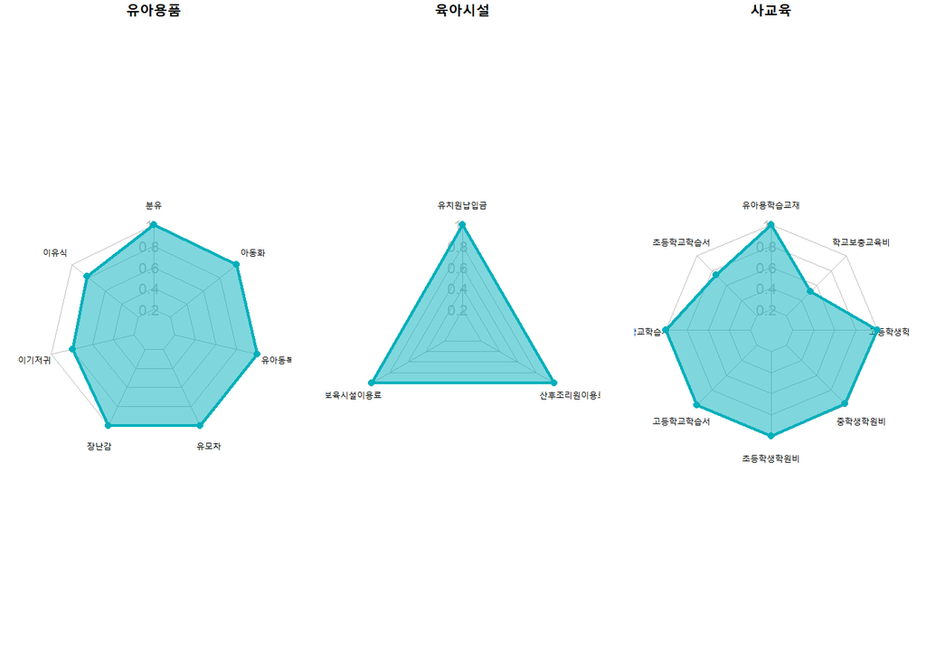

```r
result.list = list()
result.list[[1]] <- result.grapf.care
result.list[[2]] <- result.grapf.facility
result.list[[3]] <- result.grapf.edu

op <- par(mar = c(1,1,1,1))
par(mfrow = c(1,3))

titles = c("유아용품","육아시설","사교육")

for(i in 1:length(result.list)){
  result <- result.list[[i]]

  result <- result[["coefficients"]][-1,c(1,4)]
  result <- cbind(result, "1-pvalue" = 1 - result[, 2])
  result <- t(result[,3])
  pvalue <- result[1,]


  result <- rbind(result, "Max" = 1.0)
  result <- rbind(result, "Min" = 0.0)
  result <- rbind(result, pvalue)
  result <- result[-1,]
  result <- data.frame(result)
  create_beautiful_radarchart(
    data = result, caxislabels = c(0.2, 0.4, 0.6, 0.8, 1.0),
    title = titles[i]
  )
}
```

```r
par(op)
```